# Generalized Canonical Correlation with missing individuals - Examples

Dolors Pelegrí-Sisó, Guillermo Palou Márquez and Juan R. Gonzalez

Institute for Global Health (ISGlobal), Barcelona, Spain Bioinformatics Research Group in Epidemiolgy (BRGE) https://brge.isglobal.org

2020-09-14

#### Package

mgcca 0.9.9

# 1 Introduction

This manual describes how to perform gcca to integrate multiple tables, using the `mgcca` function. The `mgcca` function is designed for small tables, for omics data to work with omics dataset we have implemented the `mgcca_bd` function, which allows to work with large number of variables. We will first show the calculations with `mgcca` and later with `mgcca_bd.`

First, we have to install `mgcca` and `BigDataStatMeth` packages, for further information about installation, please see vignette for `mgcca` package.

```r
# rm(list=ls())
#devtools::install_github("isglobal-brge/mgcca")
library(mgcca)
```

Load other necessary libraries.

```r
# utility library
library(R.utils)

# libraries needed by TCGA data
library(curatedTCGAData)
library(TCGAutils)

# Libraries needed by mgcca package
library(MultiAssayExperiment)
library(RSpectra)
library(impute)

# Benchmark
library(microbenchmark)
```

# 2 Download TCGA data

Data used to perform analysis was data referred to assays RNASeq (Normalized) and Methilation from Adrenocortical carcinoma. We can check the available cancer codes and assays in TCGA repositories. Let’s choose ACC cancer, and two assays: RNA-seq and Methylation.

```r
# Available cancer codes and assays
curatedTCGAData(diseaseCode = "*", assays = "*", dry.run = TRUE)
```

```
## Available Cancer codes:
##  ACC BLCA BRCA CESC CHOL COAD DLBC ESCA GBM HNSC KICH
##  KIRC KIRP LAML LGG LIHC LUAD LUSC MESO OV PAAD PCPG
##  PRAD READ SARC SKCM STAD TGCT THCA THYM UCEC UCS UVM
## Available Data Types:
##  CNACGH CNACGH_CGH_hg_244a
##  CNACGH_CGH_hg_415k_g4124a CNASeq CNASNP
##  CNVSNP GISTIC_AllByGene GISTIC_Peaks
##  GISTIC_ThresholdedByGene Methylation
##  Methylation_methyl27 Methylation_methyl450
##  miRNAArray miRNASeqGene mRNAArray
##  mRNAArray_huex mRNAArray_TX_g4502a
##  mRNAArray_TX_g4502a_1
##  mRNAArray_TX_ht_hg_u133a Mutation
##  RNASeq2GeneNorm RNASeqGene RPPAArray
```

```r
# MultiAssayExperiment created with two assays: RNA-seq and Methylation
multiassayexperiment <- curatedTCGAData("ACC",c("RNASeq2GeneNorm","Methylation" ), FALSE)
```

Now let’s check how this MultiAssayExperiment looks like.

```r
class(multiassayexperiment)
```

```
## [1] "MultiAssayExperiment"
## attr(,"package")
## [1] "MultiAssayExperiment"
```

```r
multiassayexperiment
```

```
## A MultiAssayExperiment object of 2 listed
##  experiments with user-defined names and respective classes.
##  Containing an ExperimentList class object of length 2:
##  [1] ACC_RNASeq2GeneNorm-20160128: SummarizedExperiment with 20501 rows and 79 columns
##  [2] ACC_Methylation-20160128: SummarizedExperiment with 485577 rows and 80 columns
## Features:
##  experiments() - obtain the ExperimentList instance
##  colData() - the primary/phenotype DataFrame
##  sampleMap() - the sample availability DFrame
##  `$`, `[`, `[[` - extract colData columns, subset, or experiment
##  *Format() - convert into a long or wide DataFrame
##  assays() - convert ExperimentList to a SimpleList of matrices
```

```r
# Methylation data
assay(multiassayexperiment[[1]])[1:5,1:5]
```

```
##       TCGA-OR-A5J1-01A-11R-A29S-07 TCGA-OR-A5J2-01A-11R-A29S-07
## A1BG                       16.3305                       9.5987
## A1CF                        0.0000                       0.0000
## A2BP1                      17.2911                       5.6368
## A2LD1                     182.3919                     239.1584
## A2ML1                      54.7550                       0.0000
##       TCGA-OR-A5J3-01A-11R-A29S-07 TCGA-OR-A5J5-01A-11R-A29S-07
## A1BG                       20.7377                    1696.6615
## A1CF                        0.5925                       1.5492
## A2BP1                       8.8876                       6.1967
## A2LD1                     138.8831                      63.9349
## A2ML1                       1.7775                      49.5740
##       TCGA-OR-A5J6-01A-31R-A29S-07
## A1BG                      600.1618
## A1CF                        0.0000
## A2BP1                       4.4709
## A2LD1                     237.3520
## A2ML1                       1.1177
```

```r
dim(assay(multiassayexperiment[[1]]))
```

```
## [1] 20501    79
```

```r
# RNA-seq data
assay(multiassayexperiment[[2]])[1:5,1:5]
```

```
## <5 x 5> matrix of class DelayedMatrix and type "double":
##            TCGA-OR-A5J1-01A-11D-A29J-05 ... TCGA-OR-A5J5-01A-11D-A29J-05
## cg00000029                    0.1198770   .                    0.5344261
## cg00000108                           NA   .                           NA
## cg00000109                           NA   .                           NA
## cg00000165                    0.9031999   .                    0.9288116
## cg00000236                    0.8797038   .                    0.9312138
```

```r
dim(assay(multiassayexperiment[[2]]))
```

```
## [1] 485577     80
```

```r
# We can see there are some missing values (NA and/or 0)
table(is.na(assay(multiassayexperiment[[1]])))
```

```
##
##   FALSE
## 1619579
```

```r
table(is.na(assay(multiassayexperiment[[2]])))
```

```
##
##    FALSE     TRUE
## 31670265  7175895
```

# 3 Data imputation

As observed above, we can impute the missing values using K-Nearest Neighbors method (KNN) from `impute.knn` package implemented in our package with the function `impute`. Only NA’s will be imputed by default. However, 0 values can (if desired) be imputed aswell (`impute.zero = TRUE`). Take into account that samples must be columns and features must be rows (this is expected by the `impute.knn` function by default).

```r
# Arguments:
# subset: MultiAssayExperiment
# method: knn for K-Nearest Neighbors or
# k: Number of neighbors to be used in the imputation
# rowmax: maximum percent missing data allowed in any row (default 50%). For any rows with more than rowmax% missing are imputed using the overall mean per sample.
# colmax: maximum percent missing data allowed in any column (default 80%). If any column has more than colmax% missing data, the program halts and reports an error.
# remove.col: To remove columns with more than colmax% missing data.
# impute.zero: To impute 0 values.

multiassayexperiment.imputed <- impute(multiassayexperiment, method = "knn",
                                       k = 10, rowmax = 0.5, colmax = 0.8,
                                       remove.col = TRUE, impute.zero = TRUE)
```

# 4 Convert `MultiAssayExperiment` into a list of assays

We need to obtain a list of tables/matrices, one for each assay, to be able to run `mgcca`. The resulting matrices will have the rows and columns transposed, i.e. samples in rows and features in columns (because this is expected by the `mgcca` function).

```r
tables_list <- getTables(multiassayexperiment.imputed)

# We assess the class, length, data and dimensions of the list of tables.
class(tables_list)
```

```
## [1] "ListMAE"
```

```r
length(tables_list)
```

```
## [1] 2
```

```r
tables_list[[1]][1:5,1:5]
```

```
##                                   A1BG      A1CF   A2BP1    A2LD1    A2ML1
## TCGA-OR-A5J1-01A-11R-A29S-07   16.3305 1073.9806 17.2911 182.3919 54.75500
## TCGA-OR-A5J2-01A-11R-A29S-07    9.5987 1149.2343  5.6368 239.1584 32.79201
## TCGA-OR-A5J3-01A-11R-A29S-07   20.7377    0.5925  8.8876 138.8831  1.77750
## TCGA-OR-A5J5-01A-11R-A29S-07 1696.6615    1.5492  6.1967  63.9349 49.57400
## TCGA-OR-A5J6-01A-31R-A29S-07  600.1618 1395.0318  4.4709 237.3520  1.11770
```

```r
tables_list[[2]][1:5,1:5]
```

```
##                              cg00000029 cg00000108 cg00000109 cg00000165
## TCGA-OR-A5J1-01A-11D-A29J-05  0.1198770  0.4900907  0.4900907 0.90319992
## TCGA-OR-A5J2-01A-11D-A29J-05  0.1071205  0.3179809  0.3179809 0.81852320
## TCGA-OR-A5J3-01A-11D-A29J-05  0.0607523  0.4391222  0.4391222 0.09301364
## TCGA-OR-A5J4-01A-11D-A29J-05  0.1570048  0.4670720  0.4670720 0.85630437
## TCGA-OR-A5J5-01A-11D-A29J-05  0.5344261  0.4969288  0.4969288 0.92881163
##                              cg00000236
## TCGA-OR-A5J1-01A-11D-A29J-05  0.8797038
## TCGA-OR-A5J2-01A-11D-A29J-05  0.2564788
## TCGA-OR-A5J3-01A-11D-A29J-05  0.2536388
## TCGA-OR-A5J4-01A-11D-A29J-05  0.9403410
## TCGA-OR-A5J5-01A-11D-A29J-05  0.9312138
```

```r
dim(tables_list[[1]])
```

```
## [1]    79 20501
```

```r
dim(tables_list[[2]])
```

```
## [1]     80 485577
```

# 5 Data preprocessing

## 5.1 Sample names

First, samples names must at least overlap between tables (there can be missing individuals, but not all of them). In TCGA data, samples names are barcodes that contain information about the type of data, batches, etc. Thus, samples names are different from among different assays. Let’s obtain the real sample ID’s from the same barcodes.

```r
# The sample ID is the first 12 characters from the sample name
for (assay in 1:length(tables_list)) {
  rownames(tables_list[[assay]]) <- substr(rownames(tables_list[[assay]]),1,12)
}

#tums <- TCGAsampleSelect(colnames(accmae), "01")
```

## 5.2 Tables containing character numbers

```r
# Check if it is character
tables_list[[1]][1,1]
```

```
## [1] 16.3305
```

```r
class(tables_list[[1]][1,1])
```

```
## [1] "numeric"
```

```r
# Use our in-house function
tables_list <- matrix.chr2num(tables_list, index = 1)

# Confirm it's numeric now
tables_list[[1]][1,1]
```

```
## [1] 16.3305
```

```r
class(tables_list[[1]][1,1])
```

```
## [1] "numeric"
```

# 6 MGCCA

Now we can run mgcca! However, due to speed limitations, let’s make a subset of data.

```r
class(tables_list[[1]])
```

```
## [1] "matrix"
```

```r
table_list.subset <- lapply(tables_list, function(x) x[,1:100])
lapply(table_list.subset, function(x) x[1:5,1:5])
```

```
## $`ACC_RNASeq2GeneNorm-20160128`
##                   A1BG      A1CF   A2BP1    A2LD1    A2ML1
## TCGA-OR-A5J1   16.3305 1073.9806 17.2911 182.3919 54.75500
## TCGA-OR-A5J2    9.5987 1149.2343  5.6368 239.1584 32.79201
## TCGA-OR-A5J3   20.7377    0.5925  8.8876 138.8831  1.77750
## TCGA-OR-A5J5 1696.6615    1.5492  6.1967  63.9349 49.57400
## TCGA-OR-A5J6  600.1618 1395.0318  4.4709 237.3520  1.11770
##
## $`ACC_Methylation-20160128`
##              cg00000029 cg00000108 cg00000109 cg00000165 cg00000236
## TCGA-OR-A5J1  0.1198770  0.4900907  0.4900907 0.90319992  0.8797038
## TCGA-OR-A5J2  0.1071205  0.3179809  0.3179809 0.81852320  0.2564788
## TCGA-OR-A5J3  0.0607523  0.4391222  0.4391222 0.09301364  0.2536388
## TCGA-OR-A5J4  0.1570048  0.4670720  0.4670720 0.85630437  0.9403410
## TCGA-OR-A5J5  0.5344261  0.4969288  0.4969288 0.92881163  0.9312138
```

## 6.1 mgcca for small data

Run mgcca, select the grouping variable for the plot, and finally plot the result.

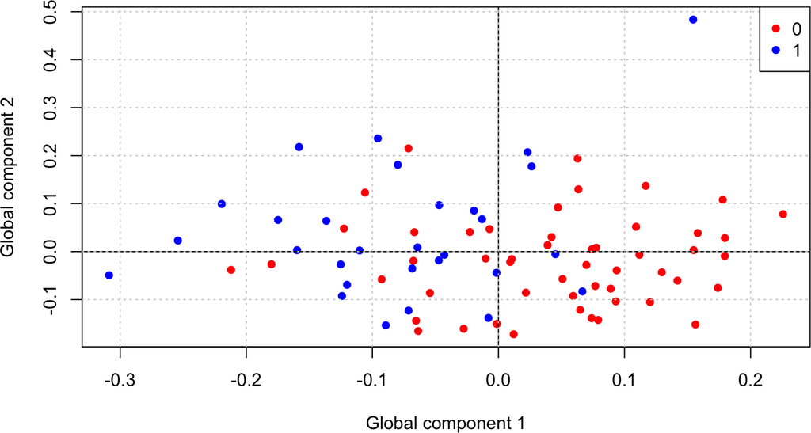

```r
# mgcca
mgcca.result <- mgcca(table_list.subset, method="penalized", lambda=c(0.75,1))

# grouping variable from the original MultiAssayExperiment
# In this case, as example, the vital status of the patients with ACC cancer.
group <- factor(multiassayexperiment$vital_status)

#plot
plotInds(mgcca.result, group=group, pos.leg = "topright")
```

## 6.2 mgcca_bd for Omics data

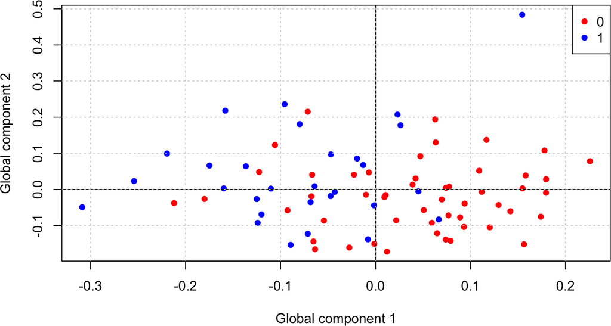

```r
# mgcca
mgcca.result.bd <- mgcca(table_list.subset, method="penalized", lambda=c(0.75,1))

# grouping variable from the original MultiAssayExperiment
group <- factor(multiassayexperiment$vital_status)

#plot
plotInds(mgcca.result.bd, group=group, pos.leg = "topright")
```